# STOR 455 Homework #8

25 points - Due 4/13 at 5:00pm

**Situation (again):** Suppose that you are interested in purchasing a used car. How much should you expect to pay? Obviously the price will depend on the type of car you get (the model) and how much it’s been used. For this assignment you will investigate how the price might depend on the age, mileage, and the model of car.

**Data Source:** Your sample of cars will again be taken from the UsedCar CSV file on Sakai. The data was acquired by scraping TrueCar.com for used car listings on 9/24/2017 and contains more than 1.2 million used cars.

For this assignment, you will need to select six new samples, each with *exactly* 50 vehicles, for six different *Model* of used vehicles for sale in North Carolina from the UsedCar dataset. There will likely be more than 50 of your selected models for sale in North Carolina, so you should randomly select those 50 vehicles from the larger number that are available. The six models of vehicles should be selected such that three models of vehicles are selected from Japanese companies, and another three from US companies (i.e. *Make*; It does not matter where the cars were actually manufactured). Within each country, you should select a compact car, a mid-sized car, and a SUV (Note that the country and types of vehicles are not given in the data and are for you to determine). You should add new variables to the dataframes for the country of the company and type of vehicle (compact vs mid-sized vs SUV) and combine these six samples into one dataframe (just as rbind was used in a previous assignment). When selecting these samples make sure to use set.seed(). This will select the same sample each time that you run (and knit) your code.The code below is an example of how you could select a random sample of 50 cars for a given model:

# Data import and preprossing:

```r
library(readr)
UsedCars <- read_csv("UsedCars.csv")
```

```r
StateOfMyChoice = "NC"
MakeOfMyChoice1 = "Honda"
MakeOfMyChoice2 = "Ford"

NCUsedCars_Honda = subset(UsedCars, Make=="Honda" & State=="NC")
NCUsedCars_Ford = subset(UsedCars, Make=="Ford" & State=="NC")

NCUsedCars_Honda$Make[which(NCUsedCars_Honda$Make=='Honda')]<-'JP'
NCUsedCars_Ford$Make[which(NCUsedCars_Ford$Make=='Ford')]<-'USA'
```

```r
# Suppose that NCUsedCars_Honda is a subset of
# only Hondas sold in NC from the Usedcars dataset.
library(dplyr)
```

```r
set.seed(8675309)
FocusSE = sample_n(subset(NCUsedCars_Ford, Model=='FocusSE'), 50)
FusionSE = sample_n(subset(NCUsedCars_Ford, Model=='FusionSE'), 50)
EdgeSEL = sample_n(subset(NCUsedCars_Ford, Model=='EdgeSEL'), 50)

Civic = sample_n(subset(NCUsedCars_Honda, Model=='Civic'), 50)
Accord = sample_n(subset(NCUsedCars_Honda, Model=='Accord'), 50)
Pilot4WD = sample_n(subset(NCUsedCars_Honda, Model=='Pilot4WD'),50)

data= rbind(FocusSE,Civic,FusionSE,Accord,EdgeSEL,Pilot4WD)
data$Model[which(data$Model=='FocusSE')]<-'cam'
data$Model[which(data$Model=='Civic')]<-'cam'
data$Model[which(data$Model=='FusionSE')]<-'mid'
data$Model[which(data$Model=='Accord')]<-'mid'
data$Model[which(data$Model=='EdgeSEL')]<-'suv'
data$Model[which(data$Model=='Pilot4WD')]<-'suv'

names(data)[8] = "Country"
names(data)[9] = "Type"
```

# 1

Produce a set of side-by-side boxplots to compare the price distributions of your three types of vehicles (not the models). Comment on any obvious differences in the distributions.  
*Compared with cam and mid size, suv size has more variance and is much more spread out of price.*

```r
boxplot(Price ~ Type, data = data)
means = tapply(data$Price, data$Type, mean)
points(means, col="red", pch=4)
```

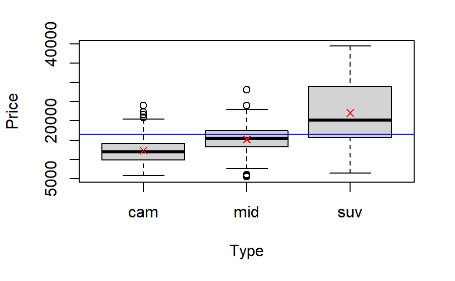

```r
abline(h = mean(data$Price), col = "blue")
```

# 2

Produce summary statistics (mean and standard deviation) for each of the groups (vehicle types) AND the entire sample of vehicle prices.

```r
tapply(data$Price, data$Type, mean)
```

```
     cam      mid      suv
12371.78 15216.29 22063.37
```

```r
tapply(data$Price, data$Type, sd)
```

```
     cam      mid      suv
3757.270 4031.583 8629.474
```

```r
mean(data$Price)
```

```
[1] 16550.48
```

```r
sd(data$Price)
```

```
[1] 7163.259
```

# 3

Based on just what you see in the boxplots and summary statistics comment on whether you think there are significant differences in the mean prices among your three vehicle types. Also comment on any concerns you see about the conditions for the ANOVA for means model.  
*I think there is a significant difference in the mean price among 3 types of cars. From seeing sd data we know that constant variance might be a issue because the one of suv is more than double two of the others.(8629>3757×2 8629>4031×2)*

# 4

Construct an ANOVA model for the mean price by vehicle type. Include the output showing the ANOVA table; state hypotheses, and provide a conclusion in the context of your data.  
*Ho: μ1=μ2=…=μK Ha: Some μi≠μj*  
*another way to write it*  
*Ho: α1=α2=…=αK=0 Ha: Some αi≠0*  
*H0: There is no difference in means between Types of cars.*  
*Ha:there is at least one type of cars that the mean is different.*  
*Since P value is small, there is a significant difference in mean price between different types of cars.*

```r
PT=aov(Price~factor(Type),data=data)
PT
```

```
Call:
   aov(formula = Price ~ factor(Type), data = data)

Terms:
                factor(Type)   Residuals
Sum of Squares    4963355280 10379017483
Deg. of Freedom            2         297

Residual standard error: 5911.53
Estimated effects may be unbalanced
```

```r
summary(PT)
```

```
              Df    Sum Sq   Mean Sq F value Pr(>F)
factor(Type)   2 4.963e+09 2.482e+09   71.01 <2e-16
Residuals    297 1.038e+10 3.495e+07

factor(Type) ***
Residuals
---
Signif. codes:
0 ‘***’ 0.001 ‘**’ 0.01 ‘*’ 0.05 ‘.’ 0.1 ‘ ’ 1
```

# 5

Produce plots and/or summary statistics to comment on the appropriateness of the following conditions for your data: normality of the residuals, and equality of the variances. If you find that the conditions are *not* met, You can still continue with analysis of your data for this homework. We will soon discuss how to deal with violations of these conditions.  
*equality: There is a little bit falling trend on the right side.*  
*normality: There is a little bit questionable because both of the tails fall off the line.*

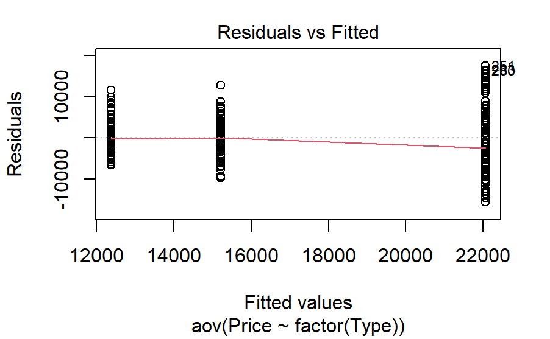

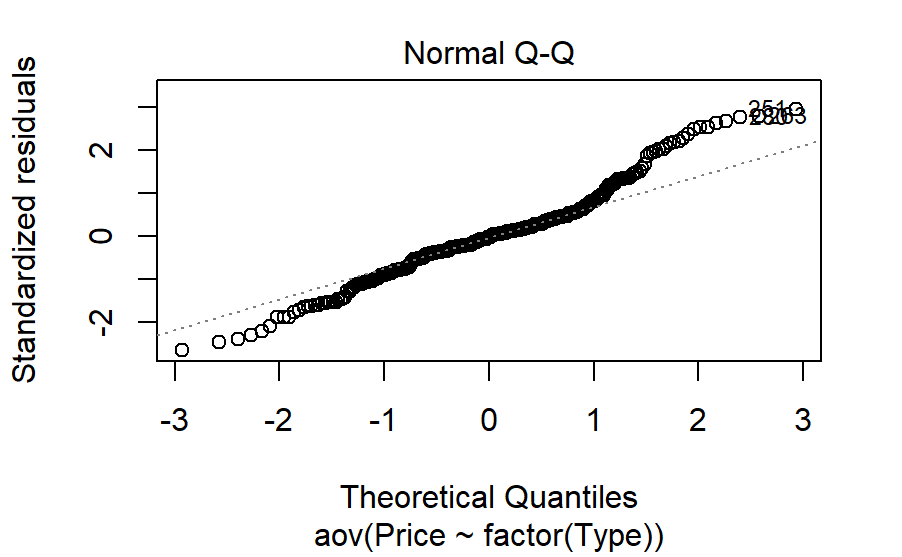

```r
plot(PT, 1:2)
```

# 6

If your ANOVA model indicates that there are significant differences among the vehicle type price means, discuss where the significant differences occur using Tukey HSD methods. If your ANOVA indicates there are not significant differences among the vehicle type price means, determine how different your means prices would need to be in order to find a significant difference using the Tukey HSD methods.  
*From the graph and small P value we know that significant difference occur in each pair of them, especially in suv and the others.*

```r
TukeyHSD(PT)
```

```
  Tukey multiple comparisons of means
    95% family-wise confidence level

Fit: aov(formula = Price ~ factor(Type), data = data)

$`factor(Type)`
           diff       lwr       upr     p adj
mid-cam 2844.51  875.2522  4813.768 0.0021864
suv-cam 9691.59 7722.3322 11660.848 0.0000000
suv-mid 6847.08 4877.8222  8816.338 0.0000000
```

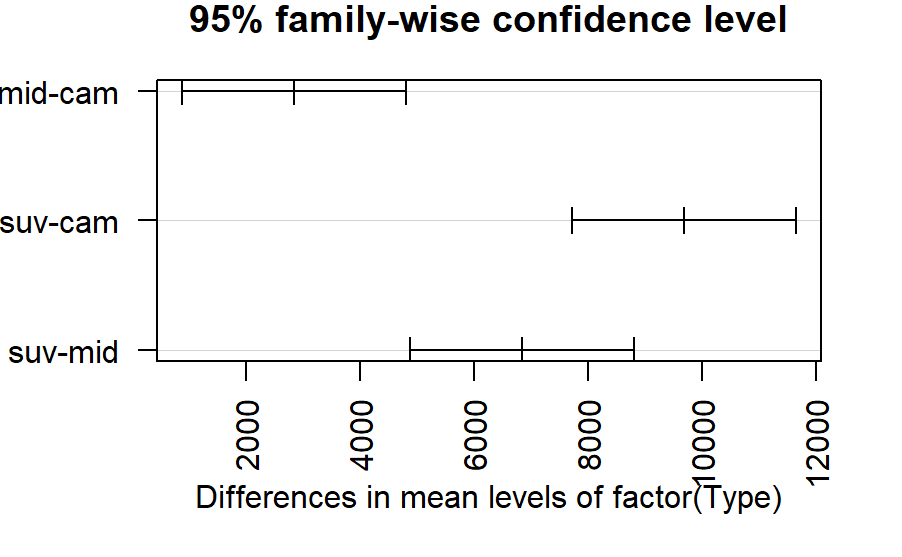

```r
hsd = TukeyHSD(PT)
plot(hsd, las=2)
```

# 7

Construct an ANOVA model for the mean price using the country of the company and the type of vehicle as predictors (without an interaction). Include the output showing the ANOVA table; state hypotheses and provide a conclusion in the context of your data. If your ANOVA model indicates there are significant differences among the vehicle price means: Discuss where the significant differences occur using Tukey HSD methods.  
*Ho: α1 = α2=…=αK=0 Ha:some αk≠0*  
*Ho: β1 = β2=…=βj=0 Ha:some βj≠0*  
*H0: There is no difference in means between Types of cars and There is no difference in means between countries.*  
*Ha:there is at least one different type or country where the mean is different.*  
*Since P value is small, we have 95% confidence to say that there is a significant difference in mean price between different subgroups(counties and types of cars).*  
*From the small P value we know that significant difference occur in each subgroups, especially in suv and the others.*

```r
amod = aov(Price~factor(Type)+Country, data=data)
summary(amod)
```

```
              Df    Sum Sq   Mean Sq F value Pr(>F)
factor(Type)   2 4.963e+09 2.482e+09  71.779 <2e-16
Country        1 1.452e+08 1.452e+08   4.199 0.0413
Residuals    296 1.023e+10 3.457e+07

factor(Type) ***
Country      *
Residuals
---
Signif. codes:
0 ‘***’ 0.001 ‘**’ 0.01 ‘*’ 0.05 ‘.’ 0.1 ‘ ’ 1
```

```r
TukeyHSD(amod)
```

```
  Tukey multiple comparisons of means
    95% family-wise confidence level

Fit: aov(formula = Price ~ factor(Type) + Country, data = data)

$`factor(Type)`
           diff       lwr      upr     p adj
mid-cam 2844.51  885.7404  4803.28 0.0020526
suv-cam 9691.59 7732.8204 11650.36 0.0000000
suv-mid 6847.08 4888.3104  8805.85 0.0000000

$Country
            diff       lwr      upr     p adj
USA-JP -1391.333 -2727.529 -55.1375 0.0413219
```

# 8

Produce plots and/or summary statistics to comment on the appropriateness of the following conditions for your data: normality of the residuals, and equality of the variances.  
*equality: There is a little bit falling trend on the right side.*  
*normality: There is a little bit questionable because both of the tails fall off the line.*

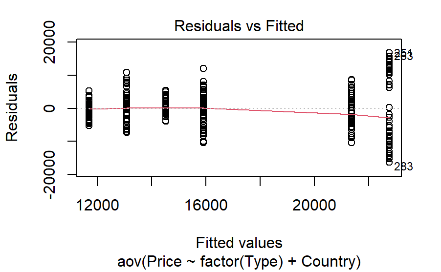

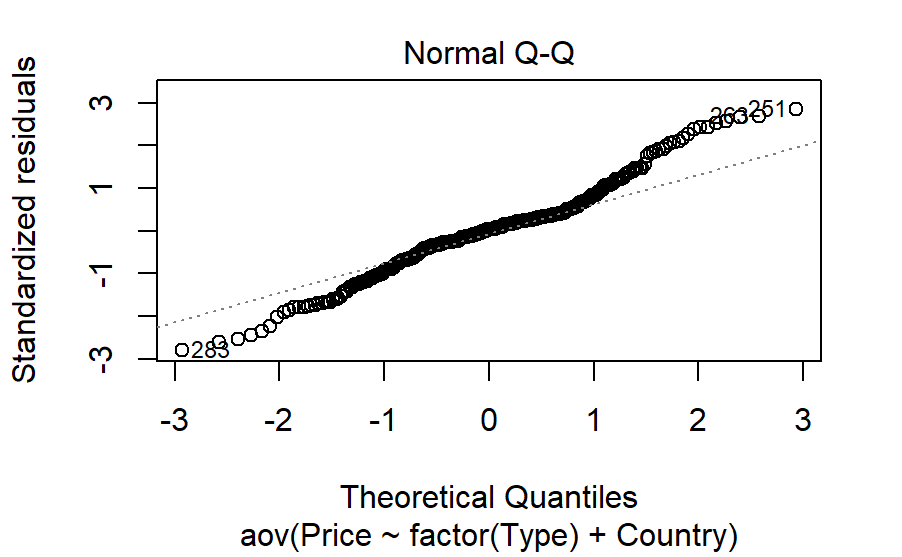

```r
plot(amod, 1:2)
```

# 9

Construct an ANOVA model for the mean price using the country of the company and the type of vehicle as predictors with the interaction. Include the output showing the ANOVA table; state hypotheses and provide a conclusion in the context of your data. If your ANOVA indicates that there are significant differences among the car price means: Discuss where the significant differences occur using Tukey HSD methods.  
*Ho: all αK=0 Ha:some αk≠0*  
*Ho: all βj=0 Ha:some βj≠0*  
*Ho: all γkj=0 Ha:some γkj≠0*  
*From P values (<2e-16,0.0413,0.3491), we have 95% confidence to say that there is main effects, but there is no intersection effects. Here we are using different criterias in these two test, TukeyHSD have some significant difference is because that it considers the Type one error and adjust the P values. It is also related with the sample size.*

```r
modint = aov(Price ~Type+Country+ Type*Country, data=data)
summary(modint)
```

```
              Df    Sum Sq   Mean Sq F value Pr(>F)
Type           2 4.963e+09 2.482e+09  71.806 <2e-16
Country        1 1.452e+08 1.452e+08   4.201 0.0413
Type:Country   2 7.300e+07 3.650e+07   1.056 0.3491
Residuals    294 1.016e+10 3.456e+07

Type         ***
Country      *
Type:Country
Residuals
---
Signif. codes:
0 ‘***’ 0.001 ‘**’ 0.01 ‘*’ 0.05 ‘.’ 0.1 ‘ ’ 1
```

```r
TukeyHSD(modint)
```

```
  Tukey multiple comparisons of means
    95% family-wise confidence level

Fit: aov(formula = Price ~ Type + Country + Type * Country, data = data)

$Type
           diff       lwr       upr     p adj
mid-cam 2844.51  886.0445  4802.975 0.0020497
suv-cam 9691.59 7733.1245 11650.055 0.0000000
suv-mid 6847.08 4888.6145  8805.545 0.0000000

$Country
            diff       lwr       upr     p adj
USA-JP -1391.333 -2727.313 -55.35363 0.0412897

$`Type:Country`
                     diff         lwr        upr
mid:JP-cam:JP     2074.44  -1298.3802  5447.2602
suv:JP-cam:JP    10112.96   6740.1398 13485.7802
cam:USA-cam:JP   -1623.80  -4996.6202  1749.0202
mid:USA-cam:JP    1990.78  -1382.0402  5363.6002
suv:USA-cam:JP    7646.42   4273.5998 11019.2402
suv:JP-mid:JP     8038.52   4665.6998 11411.3402
cam:USA-mid:JP   -3698.24  -7071.0602  -325.4198
mid:USA-mid:JP     -83.66  -3456.4802  3289.1602
suv:USA-mid:JP    5571.98   2199.1598  8944.8002
cam:USA-suv:JP  -11736.76 -15109.5802 -8363.9398
mid:USA-suv:JP   -8122.18 -11495.0002 -4749.3598
suv:USA-suv:JP   -2466.54  -5839.3602   906.2802
mid:USA-cam:USA   3614.58    241.7598  6987.4002
suv:USA-cam:USA   9270.22   5897.3998 12643.0402
suv:USA-mid:USA   5655.64   2282.8198  9028.4602
                    p adj
mid:JP-cam:JP   0.4905085
suv:JP-cam:JP   0.0000000
cam:USA-cam:JP  0.7384206
mid:USA-cam:JP  0.5373921
suv:USA-cam:JP  0.0000000
suv:JP-mid:JP   0.0000000
cam:USA-mid:JP  0.0223348
mid:USA-mid:JP  0.9999997
suv:USA-mid:JP  0.0000490
cam:USA-suv:JP  0.0000000
mid:USA-suv:JP  0.0000000
suv:USA-suv:JP  0.2912596
mid:USA-cam:USA 0.0277004
suv:USA-cam:USA 0.0000000
suv:USA-mid:USA 0.0000354
```

# 10

Produce two interaction plots for the previous model. If you found significant interactions in your hypothesis test, comment on how these interactions are shown in the plot. If you did not find significant interactions in your hypothesis test, comment on how the (lack of) interactions are shown in the plot.  
*There is no significant intersections because the slope of these lines are similar, which means that there is similar change from going to JP to USA for any level of the size of cars, and there is similar change from going to cam to mid to suv for either given countries.*

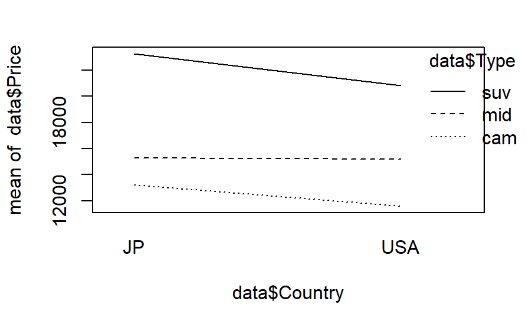

```r
interaction.plot(data$Country, data$Type, data$Price)
```

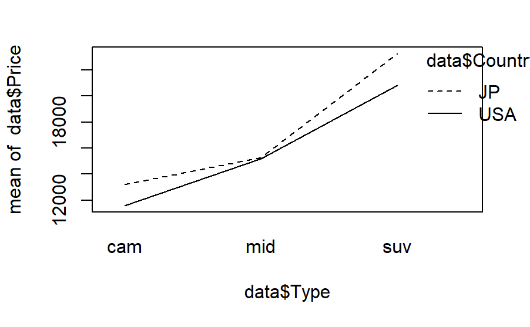

```r
interaction.plot(data$Type, data$Country, data$Price)
```

# 11

Recall that we can also handle a categorical predictor with multiple categories using ordinary multiple regression if we create indicator variables for each category and include all but one of the indicators in the model. Run an ordinary multiple regression to predict *Price* using the country of the company, the type of vehicle, and the interaction between the two as predictors. Interpret each of the coefficients in the “dummy” regression by what they mean in the context of mean prices.  
*interpretation:*  
*the mean price of JP_com=13183.7*  
*the mean price of JP_mid=13183.7+2074.4=15258.1*  
*the mean price of JP_suv=13183.7+10113.0=23296.7*  
*the mean price of USA_com=13183.7-1623.8=11559.9*  
*the mean price of* *USA_mid=13183.7-1623.8+2074.4+1540.1=15174.4*  
*the mean price of* *USA_suv=13183.7-1623.8+10113.0-842.7=20830.2*

```r
mod=lm(Price~factor(Country)+factor(Type)+factor(Country)*factor(Type),data=data)
summary(mod)
```

```
Call:
lm(formula = Price ~ factor(Country) + factor(Type) + factor(Country) *
    factor(Type), data = data)

Residuals:
     Min       1Q   Median       3Q      Max
-16896.6  -3080.9     63.3   2532.5  16178.4

Coefficients:
                                   Estimate
(Intercept)                         13183.7
factor(Country)USA                  -1623.8
factor(Type)mid                      2074.4
factor(Type)suv                     10113.0
factor(Country)USA:factor(Type)mid   1540.1
factor(Country)USA:factor(Type)suv   -842.7
                                   Std. Error
(Intercept)                             831.4
factor(Country)USA                     1175.8
factor(Type)mid                        1175.8
factor(Type)suv                        1175.8
factor(Country)USA:factor(Type)mid     1662.8
factor(Country)USA:factor(Type)suv     1662.8
                                   t value Pr(>|t|)
(Intercept)                         15.857  < 2e-16
factor(Country)USA                  -1.381   0.1683
factor(Type)mid                      1.764   0.0787
factor(Type)suv                      8.601  4.8e-16
factor(Country)USA:factor(Type)mid   0.926   0.3551
factor(Country)USA:factor(Type)suv  -0.507   0.6127

(Intercept)                        ***
factor(Country)USA
factor(Type)mid                    .
factor(Type)suv                    ***
factor(Country)USA:factor(Type)mid
factor(Country)USA:factor(Type)suv
---
Signif. codes:
0 ‘***’ 0.001 ‘**’ 0.01 ‘*’ 0.05 ‘.’ 0.1 ‘ ’ 1

Residual standard error: 5879 on 294 degrees of freedom
Multiple R-squared:  0.3377,    Adjusted R-squared:  0.3265
F-statistic: 29.99 on 5 and 294 DF,  p-value: < 2.2e-16
```

```r
13183.7+2074.4
```

```
[1] 15258.1
```

```r
13183.7+10113.0
```

```
[1] 23296.7
```

```r
13183.7-1623.8
```

```
[1] 11559.9
```

```r
13183.7-1623.8+2074.4+1540.1
```

```
[1] 15174.4
```

```r
13183.7-1623.8+10113.0-842.7
```

```
[1] 20830.2
```

# 12

```r
mod1=lm(Price~factor(Country)+factor(Type)+factor(Country)*factor(Type)+Mileage,data=data)
anova(mod1)
```

```
Analysis of Variance Table

Response: Price
                              Df     Sum Sq
factor(Country)                1  145185633
factor(Type)                   2 4963355280
Mileage                        1 5685484847
factor(Country):factor(Type)   2  196027852
Residuals                    293 4352319151
                                Mean Sq  F value
factor(Country)               145185633   9.7740
factor(Type)                 2481677640 167.0676
Mileage                      5685484847 382.7493
factor(Country):factor(Type)   98013926   6.5983
Residuals                      14854332
                                Pr(>F)
factor(Country)               0.001948 **
factor(Type)                 < 2.2e-16 ***
Mileage                      < 2.2e-16 ***
factor(Country):factor(Type)  0.001574 **
Residuals
---
Signif. codes:
0 ‘***’ 0.001 ‘**’ 0.01 ‘*’ 0.05 ‘.’ 0.1 ‘ ’ 1
```

```r
line1=lm(Price ~ Mileage, data=FocusSE)
line2=lm(Price ~ Mileage, data=Civic)
line3=lm(Price ~ Mileage, data=FusionSE)
line4=lm(Price ~ Mileage, data=Accord)
line5=lm(Price ~ Mileage, data=EdgeSEL)
line6=lm(Price ~ Mileage, data=Pilot4WD)

plot(Price ~ Mileage, data=data)
abline(line1)
```

```r
abline(line2, col='red')
abline(line3, col='blue')
```

```r
abline(line4, col='yellow')
abline(line5, col='green')
```

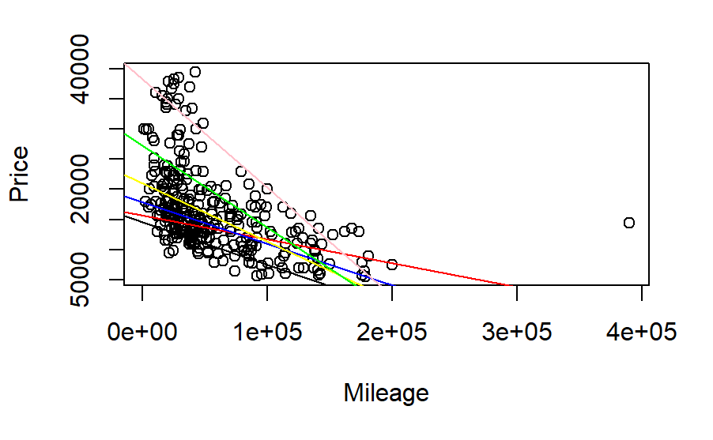

```r
abline(line6, col='pink')
```